# Test+a+Perceptual+Phenomenon+zh

### 统计学：检验心理学现象

在下方单元格中回答问题并执行相关代码，你可以 参考项目指导 并在正式提交前查看 [项目要求](https://review.udacity.com/#!/rubrics/305/view)。提交时请将 Jupyter notebook 导出成 HTML 或者 PDF 进行提交（File -> Download As）。

背景信息

在一个Stroop （斯特鲁普）任务中，参与者得到了一列文字，每个文字都用一种油墨颜色展示。参与者的任务是将文字的打印颜色大声说出来。这项任务有两个条件：一致文字条件，和不一致文字条件。在一致文字条件中，显示的文字是与它们的打印颜色匹配的颜色词，如“红色”、“蓝色”。在不一致文字条件中，显示的文字是与它们的打印颜色不匹配的颜色词，如“紫色”、“橙色”。在每个情况中，我们将计量说出同等大小的列表中的墨色名称的时间。每位参与者必须全部完成并记录每种条件下使用的时间。

调查问题

作为一般说明，请确保记录你在创建项目时使用或参考的任何资源。作为项目提交的一部分，你将需要报告信息来源。

(1) 我们的自变量是什么？因变量是什么？

自变量：文字条件  
因变量：不同文字条件（一致或不一致）下，参与者说出同等大小的列表中的墨色名称所花时间

(2) 此任务的适当假设集是什么？你需要以文字和数学符号方式对假设集中的零假设和对立假设加以说明，并对数学符号进行定义。你想执行什么类型的统计检验？为你的选择提供正当理由（比如，为何该实验满足你所选统计检验的前置条件）。

我们可以做如下假设：  
$H_0: \mu_c=\mu_i$，即不同的文字条件下，参与者说出同等大小的列表中的墨色名称所化的时间无显著区别  
$H_1: \mu_c≠\mu_i$，即不同的文字条件下，参与者说出同等大小的列表中的墨色名称所化的时间有显著区别  
其中：  
$\mu_c$: 一致文字条件下，参与者说出同等大小的列表中的墨色名称所花时间的总体均值 $\mu_i$: 不一致文字条件下，参与者说出同等大小的列表中的墨色名称所花时间的总体均值

执行配对样本的双尾T检验。因为样本数据集及满足以下条件：  
1）样本容量小于30且总体的统计信息（标准差，均值等）未知  
2）因为备择假设是两种情况： μc>μi 和 μc<μi ，所以用双尾检验  
3）总体近似服从正态分布 4）自变量有两种取值：文字条件一致和不一致  
5）因变量的取值是连续的  
6）样本为配对样本：同一个参与者在不同文字条件下进行测试，且参与者之间相互独立（可假设方差相等）  
7）因为备择假设是两种情况： μc>μi 和 μc<μi ，所以用双尾检验

现在轮到你自行尝试 Stroop 任务了。前往此链接，其中包含一个基于 Java 的小程序，专门用于执行 Stroop 任务。记录你收到的任务时间（你无需将时间提交到网站）。现在下载此数据集，其中包含一些任务参与者的结果。数据集的每行包含一名参与者的表现，第一个数字代表他们的一致任务结果，第二个数字代表不一致任务结果。

(3) 报告关于此数据集的一些描述性统计。包含至少一个集中趋势测量和至少一个变异测量。

[output not shown]

```python
import pandas as pd
import numpy as np
from numpy import mean, median, ptp, var, std
import math
#read data
file = 'https://s3.cn-north-1.amazonaws.com.cn/static-documents/nd002/stroopdata.csv'
data = pd.read_csv(file)

#add one colunm Incongruent - Congruent
data["Diff (In - Con)"] = data["Incongruent"] - data["Congruent"]

n = len(data) #sample size
factor = math.sqrt(n/(n-1)) #correction factor

#calculate statistics
#########集中趋势测量############################################
#mean
Con_mean = mean(data["Congruent"])
In_mean = mean(data["Incongruent"])
Diff_mean = mean(data["Diff (In - Con)"])

d1 = [Con_mean,Con_mean,Diff_mean]

#median
Con_median = median(data["Congruent"])
In_median = median(data["Incongruent"])
Diff_median = median(data["Diff (In - Con)"])

d2 = [Con_median,In_median,Diff_median]

##########变异测量##############################################
#极差
Con_ptp = ptp(data["Congruent"])
In_ptp = ptp(data["Incongruent"])
Diff_ptp = ptp(data["Diff (In - Con)"])

d3 = [Con_ptp,In_ptp,Diff_ptp]

#标准差
Con_std = std(data["Congruent"])*factor
In_std = std(data["Incongruent"])*factor
Diff_std = std(data["Diff (In - Con)"])*factor

d4 = [Con_std,In_std,Diff_std]

#变异系数
Con_n = Con_mean/Con_std
In_n = In_mean/In_std
Diff_n = Diff_mean/Diff_std

d5 = [Con_n,In_n,Diff_n]

index = list(data)
output = pd.DataFrame(list(zip(d1,d2,d3,d4,d5)), index = index, columns = ['mean','median','range','standard deviation','coefficient of variation'])
for i in list(output):
    print(i, '\n', output[i], '\n')
```

[output not shown]

(4) 提供显示样本数据分布的一个或两个可视化。用一两句话说明你从图中观察到的结果。

```
Text(0,0.5,'time - incongruent condition (s)')
```

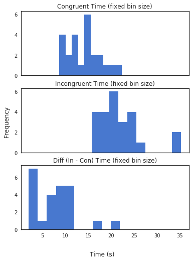

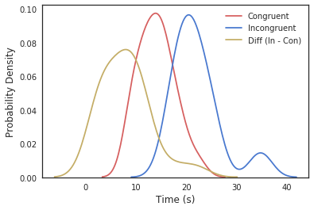

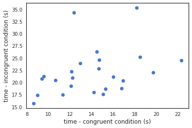

```python
# -*- coding: utf-8 -*-
"""
Created on Thu Feb 22 01:19:17 2018

@author: zhangyuchen
"""

import numpy as np
import pandas as pd
import matplotlib.pyplot as plt
import seaborn as sns
%matplotlib inline

#prepare data
file = 'https://s3.cn-north-1.amazonaws.com.cn/static-documents/nd002/stroopdata.csv'
data = pd.read_csv(file)

#add one colunm Incongruent - Congruent
data["Diff (In - Con)"] = data["Incongruent"] - data["Congruent"]

#画直方图
fig, ax = plt.subplots(3, 1, figsize=(6,8),sharex='col', sharey='row')
fig.text(0.5, 0.04, 'Time (s)', ha='center', va='center', fontsize=12)
fig.text(0.06, 0.5, 'Frequency', ha='center', va='center', rotation='vertical', fontsize=12)
for i in range(3):
    j = list(data)[i]
    dt = data[j]
    ax[i].hist(dt)
    ax[i].set_title(j + ' Time (fixed bin size)')


#画概率分布图
#for i in list(data):
#    dt = data[i]
#    sns.set_style('dark')
#    n = int((max(dt) - min(dt)) / 2)
#    sns.distplot(dt, bins=8, hist=True, kde=False, vertical=False)
#    plt.xlabel('Time (s)', fontsize=12)
#    plt.ylabel('Frequency', fontsize=12)
#    plt.title(i + ' Time (fixed bin size)')

fig = plt.figure()
sns.set(style="white", palette="muted", color_codes=True)
colors = ['r','b','y']
for i,c in list(zip(list(data),colors)):
    dt = data[i]
    ax=sns.kdeplot(dt,color=c)

plt.xlabel('Time (s)', fontsize=12)
plt.ylabel('Probability Density', fontsize=12)

#画散点图
fig = plt.figure()
x = data['Congruent']
y = data['Incongruent']
plt.scatter(x,y)
plt.xlabel('time - congruent condition (s)',fontsize = 12)
plt.ylabel('time - incongruent condition (s)',fontsize = 12)
```

通过直方图和概率密度图可以看出：  
1）数据呈正偏态分布  
2）不一致文字条件所花的时间明显多于一直文字条件所花的时间  
3）一致条件组的数据集中在10到15秒之间，而不一致条件组的数据集中在20秒左右处

通过三点图可以大致看出一致与不一致条件下一个人所花的时间有明显的相关性，前者用时较短的一般后者也相对较短，但是有一些异常值，猜测可能是被试者进行测试时注意力被分散等原因。

(5) 现在，执行统计测试并报告你的结果。你的置信水平和关键统计值是多少？你是否成功拒绝零假设？对试验任务得出一个结论。结果是否与你的期望一致？

进行双侧t检验，假设显著性水平$\alpha=5\%$，因为是双侧检验所以两边各$2.5\%$，置信水平设置为$1-\alpha=95\%$

```python
import pandas as pd
from numpy import mean, std
import math
import scipy
from scipy import stats

# load data
file = 'https://s3.cn-north-1.amazonaws.com.cn/static-documents/nd002/stroopdata.csv'
data = pd.read_csv(file)
n = len(data) #sample size
factor = math.sqrt(n/(n-1)) #correction factor

data["Diff (In - Con)"] = data["Incongruent"] - data["Congruent"]

#mean
Diff_mean = mean(data["Diff (In - Con)"])

#unbiased standard deviation
Diff_std = std(data["Diff (In - Con)"])*factor

t_statistics,p_value = scipy.stats.ttest_1samp(data["Diff (In - Con)"], 0)
print ("t statistics is: ", t_statistics)
print ("p value is: ", p_value)
```

```
t statistics is:  8.02070694411
p value is:  4.10300058571e-08
```

给定$\alpha=5\%$显著性信水平下，样本为自由度为23的配对样本，t检验统计量值为8.02，而t的临界值为$t_{\alpha/2}=+/-2.069$，t检验统计量值远大于t临界值，P值为$4.1e^{-8}$远小于$\alpha$，所以拒绝原假设，认为不同的文字条件下，参与者说出同等大小的列表中的墨色名称所花的时间有显著区别。结果与我的预期一致。

参考文献：  
1). t检验维基百科https://zh.wikipedia.org/zh-cn/學生t檢驗  
2).Interactive “Directional Stroop “ Effect Experiment” (https://faculty.washington.edu/chudler/java/readyd.html)  
3). Statistics How To (http://www.statisticshowto.com/probability-and-statistics/t-test/)  
4). http://www.statstutor.ac.uk/resources/uploaded/paired-t-test.pdf  
5). http://lagrange.univ-lyon1.fr/docs/scipy/0.17.1/generated/scipy.stats.ttest_ind_from_stats.html  
6). https://github.com/ShiChJ/DAND-Basic-Materials/blob/master/P1/t-table.jpg  
7). http://www.csic.cornell.edu/Elrod/t-test/t-test-assumptions.html